# homework3_jn2761

**i) Use graphical displays to check the normality assumption and discuss the findings. (3p)**

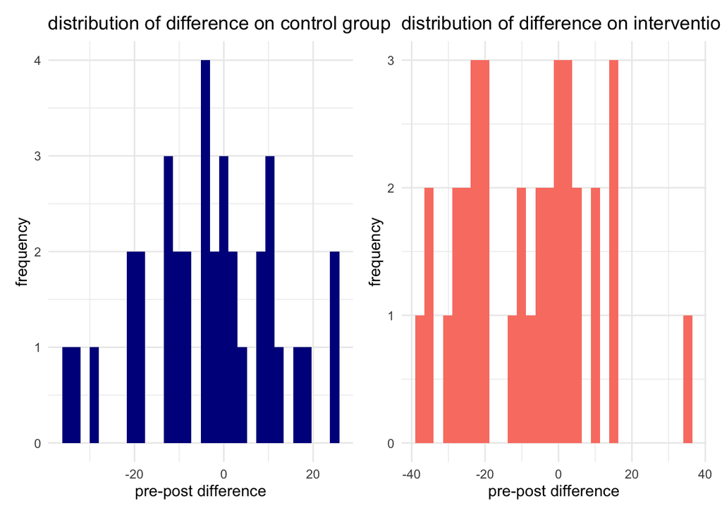

```r
knitr::opts_chunk$set(
  fig.width = 6,
    fig.asp = .6,
  out.width = "90%"
)
theme_set(theme_minimal()+theme(legend.position = "bottom"))

display_control=ggplot(Exercise_df_control, aes(x=difference)) +
  geom_histogram(fill="dark blue")+
  labs(titles = "distribution of difference on control group",
       x= "pre-post difference",
       y = "frequency"  )
display_intervention=ggplot(Exercise_df_intervention, aes(x=difference)) +
  geom_histogram(fill="salmon") +
labs(titles = "distribution of difference on intervention group",
       x= "pre-post difference",
       y = "frequency"  )

library(patchwork)

display_control+display_intervention
```

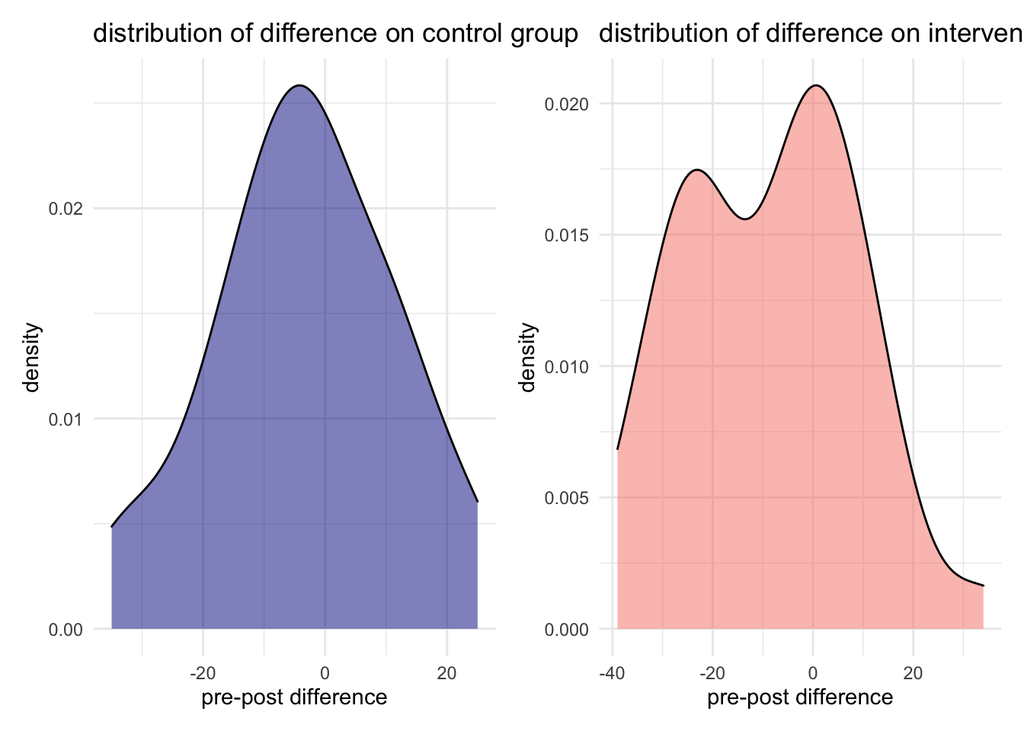

```r
display_control=ggplot(Exercise_df_control, aes(x=difference)) +
  geom_density(fill="dark blue",alpha=.5)+
  labs(titles = "distribution of difference on control group",
       x= "pre-post difference",
       y = "density"  )
display_intervention=ggplot(Exercise_df_intervention, aes(x=difference)) +
   geom_density(fill="salmon ",alpha=.5) +
labs(titles = "distribution of difference on intervention group",
       x= "pre-post difference",
       y = "density"  )
display_control+display_intervention
```

- by looking at the two ggplot, the normality assumption seem to hold for control group but not so much for intervention group.(seems like there are two major peak in the distribution of difference in intervention group)

**ii) If normality is questionable, how does this affect the tests validity and what are some possible remedies? (2p)**

- If normality is questionable, our conclusion made based on p-value will also be questionable, because we ware making our inference based on the assumpetion that the difference follow a normal distribution. Some of the remedies can be to increase sample size, because even if the populaiton distribution is not normal, when the sample size is big enough,the sampling distribution will be approximately normal. Also, we can use a more conservative p-value so that we are more cautious about the conclusion we made.

### Problem 2

We have discussed the fact that we are not guaranteed to make the correct decision by the process of hypothesis testing and there is always some level of uncertainty in statistics. The two main errors that we are trying to minimize/control are type I and type II. A type I error occurs when we reject the null hypothesis 𝐻0, when 𝐻0 is true. When we set the significance level at 5%, we are saying that we will allow ourselves to make a type I error less than 5% of the time. In practice we can only calculate this probability using a series of “what if” calculations, because we do not really know the truth. In this exercise you learn how to create your own ‘true’ scenario, simulate corresponding data, and quantify the type I error over many repetitions.

*Scenario: The average IQ score of Ivy League colleges is 120. We will assume this to be the null hypothesis (true mean is 120) with a standard deviation of 15 and a significance level of 5%. For the alternative hypothesis we will consider that the ‘true mean is less than 120’.*

Most of the time (95%) when we generate a sample from the underlying true distribution, we should fail to reject the null hypothesis since the null hypothesis is true. Let us test it!

**a) Generate one random sample of size n=20 from the underlying (null) true distribution. Calculate the test statistic, compare to the critical value and report the conclusion: 1, if you reject 𝐻0 or 0, if you fail to rejected 𝐻0. (5p) Hint: use rnorm(20, mean = 120, sd = 15)**

```r
#generae a randome sample with size=20, mean=120, sd=15
set.seed(2761)
rs1=rnorm(20, mean = 120, sd = 15)

#calculate the criticle value
(mean(rs1)-120)/(15/sqrt(20))
```

```
## [1] 0.6303571
```

```r
qnorm(0.05, mean = 0, sd = 1)
```

```
## [1] -1.644854
```

- The conclusion is 0 since our test statistic is 0.63 which is larger than -1.64, and we fail to reject the H0.

**b) Now generate 100 random samples of size n = 20 from the underlying (null) true distribution and repeat the process in part (a) for each sample (calculate the test statistic, compare to the critical value, and record 1 or 0 based on criteria above). Report the percentage of 1s and 0s respectively across the 100 samples. The percentage of 1s represents the type I error. (7.5p)**

```r
#creat two empty list
  l <- list()
result=list()

#generae 100 random sample with size=20, mean=120, sd=15 and store them in newly creatd list L, then record the decision of each random sample in list "result"
set.seed(2761)
for (i in 1:100){
l[i] <- list(rnorm(20, mean = 120, sd = 15))
}

for (i in 1:100){
result[i] = ifelse((mean(l[[i]])-120)/(15/sqrt(20)) < -1.645,1,0)
}
#convert list into columns
result_df = c(unlist(result))

#show the frequency of each decision
table(result_df)
```

```
## result_df
##  0  1
## 97  3
```

- the percentage of 1s and 0s for the current cases with 100 sample size are 0.03 for 1s and 0.97 for 0s. The precentage of type I error is 0.03 in the current cause.

**c) Now generate 1000 random samples of size n = 20 from the underlying (null) true distribution, repeat the same process, and report the percentage of 1s and 0s across the 1000 samples. (7.5p)**

```r
#create two empty list
  l <- list()
result=list()

#generae 1000 random sample with size=20, mean=120, sd=15 and store them in newly creatd list L, then record the decision of each random sample in list "result"
set.seed(2761)
for (i in 1:1000){
l[i] <- list(rnorm(20, mean = 120, sd = 15))
result[i] = ifelse((mean(l[[i]])-120)/(15/sqrt(20)) < (-1.645),1,0)
}

#convert list into columns
result_df = c(unlist(result))

#show the frequency of each decision
table(result_df)
```

```
## result_df
##   0   1
## 947  53
```

- the percentage of 1s and 0s for the current cases are 0.053 for 1s and 0.947 for 0s. The precentage of type I error is 0.053 in the current cases.*

**d) Final conclusions: compare the type I errors (percentage of 1s) from part b) and c). How do they compare to the level that we initially imposed (i.e. 0.05)? Comment on your findings. (5p)**

Notes: For this problem you are encouraged to use R for all calculations/simulations. You can follow the hints or feel free to use other functions – there are several ways to tackle these simulations. You do not need to write the test statistics, critical values, etc., but please include themain results (percentage of correct and incorrect decisions) for each part and conclusions in the main homework document. Make sure to comment your R code and don’t forget to set the seed for replicability.